# TSA project - Forecasting financial instrument prices with VECM and ARIMA models

Nadim Muhammad & Michał Kulbat

**Importing the libraries**

```r
library(xts)
library(lmtest)
library(quantmod)
library(dplyr)
library(fUnitRoots)
library(vars)
library(tseries)
library(aTSA)
library(car)
library(seasonal)
library(forecast)
library(kableExtra)
library(formattable)
library(Metrics)
library(TSEwgt)
library(tidyverse)
```

# 1.Getting data

```r
setwd("C:\\Users\\micha\\OneDrive\\Dokumenty\\QF\\GitHub\\TSA-project")

options(scipen = 10)

source("functions/function_plot_ACF_PACF_resids.R")
source("functions/testdf.R")

data <- read.csv("data/TSA_2023_project_data_1.csv")

data_train <- data[1:970,]

data_test <- data[971:1000,]

data_train$X <- as.Date(data_train$X, format = "%Y-%m-%d")

data_test$X <- as.Date(data_test$X, format = "%Y-%m-%d")
```

**Let’s also transform the `data.frame` into an `xts` object**

```r
data_train_xts <- xts(data_train[, -1], order.by = data_train$X)

data_test_xts <- xts(data_test[, -1], order.by = data_test$X)
```

# 2.Choosing time series

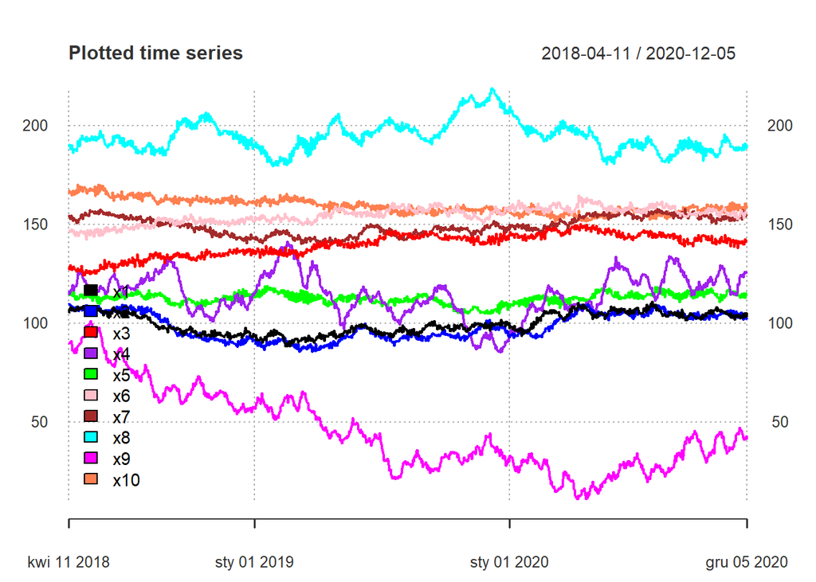

```r
plot(data_train_xts, col = c("black", "blue", "red", "purple", "green", "pink", "brown", "cyan", "magenta", "coral"), major.ticks = "years", grid.ticks.on = "years", grid.ticks.lty = 3, main = "Plotted time series", legend.loc = "bottomleft")
```

*BG test - null hypothesis: no serial correlation of any order (up to max.augmentations)*

*ADF test - null hypothesis: unit root in the time series*

```r
for (i in 1:10) {
print(i)
print(testdf(variable = data_train_xts[,i],
             max.augmentations = 3))
  }
```

```
## [1] 1
```

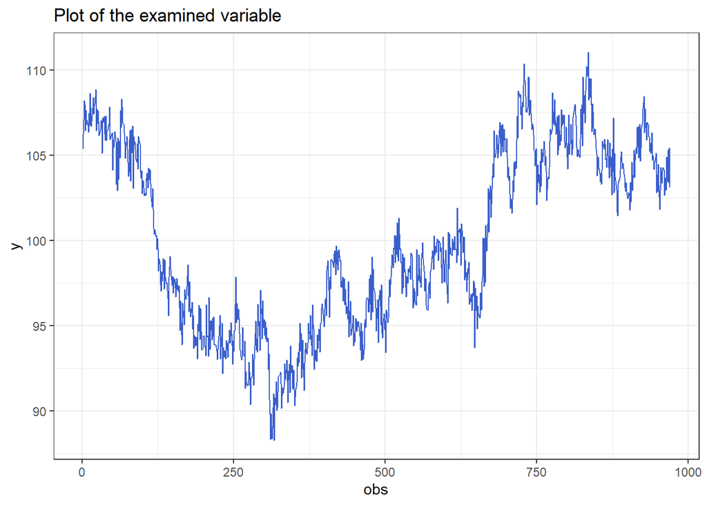

```
##   augmentations       adf     p_adf    bgodfrey         p_bg
## 1             0 -3.803259 0.0100000 264.5832955 1.719887e-59
## 2             1 -2.157827 0.2540868   2.0201728 1.552215e-01
## 3             2 -2.081606 0.2825813   0.3613083 5.477805e-01
## 4             3 -1.745467 0.4082435   0.9416020 3.318662e-01
## [1] 2
```

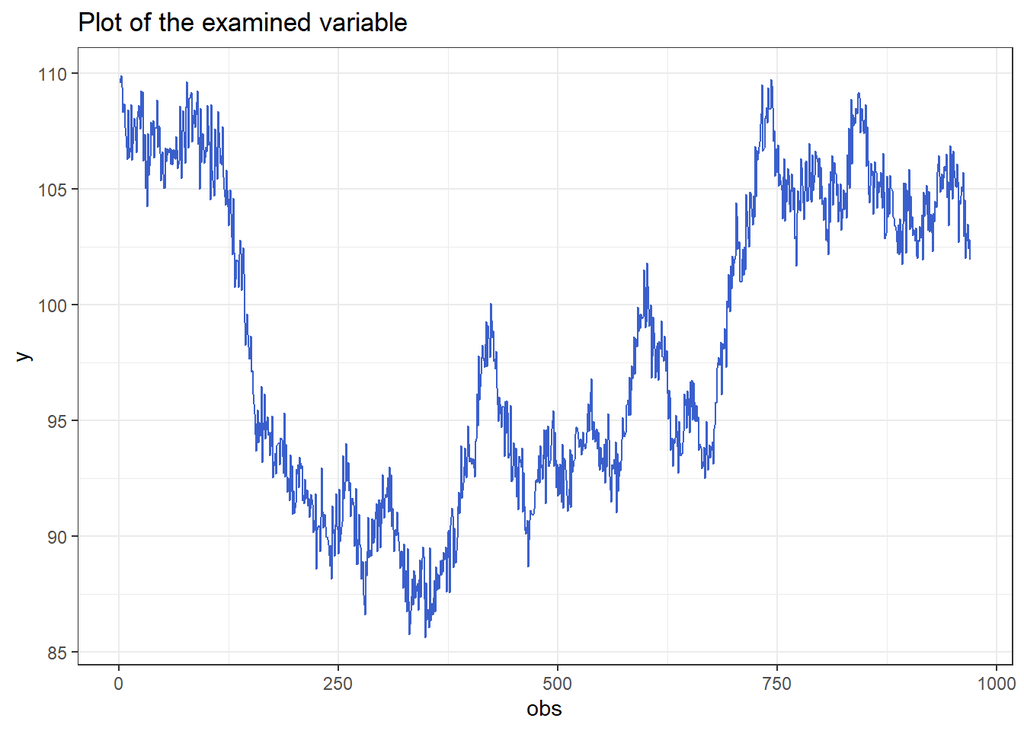

```
##   augmentations       adf      p_adf   bgodfrey         p_bg
## 1             0 -3.303984 0.01657912 264.339657 1.943587e-59
## 2             1 -2.084780 0.28139458   7.143669 7.522910e-03
## 3             2 -1.876867 0.35912092   2.241790 1.343254e-01
## 4             3 -1.578488 0.47066701   2.237972 1.346575e-01
## [1] 3
```

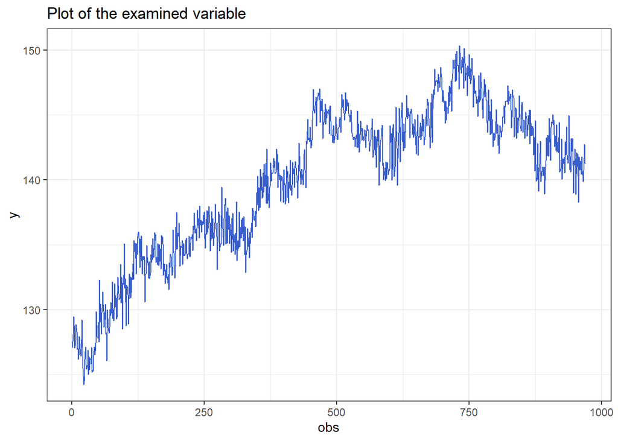

```
##   augmentations       adf      p_adf    bgodfrey         p_bg
## 1             0 -4.236743 0.01000000 216.4773277 5.306350e-49
## 2             1 -2.765207 0.06746044   1.3837714 2.394598e-01
## 3             2 -2.535913 0.11274324   0.4150733 5.194057e-01
## 4             3 -2.182995 0.24467802  17.5675287 2.772829e-05
## [1] 4
```

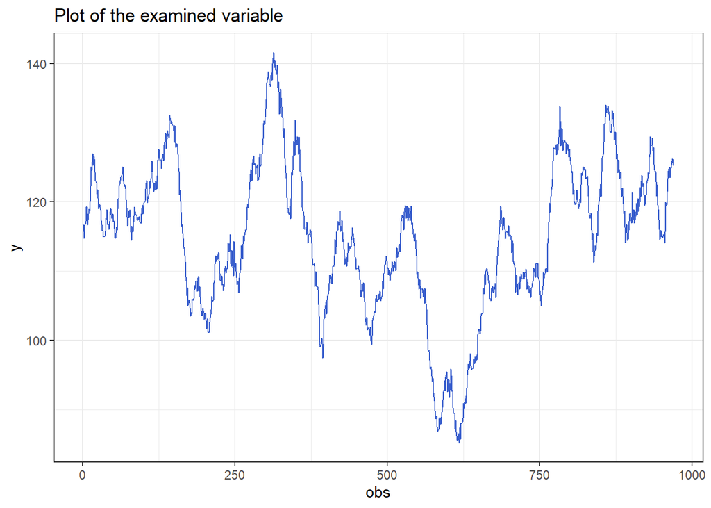

```
##   augmentations       adf      p_adf    bgodfrey      p_bg
## 1             0 -1.923499 0.34168790 0.161474268 0.6878028
## 2             1 -1.883351 0.35669671 0.003413152 0.9534123
## 3             2 -1.867504 0.36262112 0.004292036 0.9477651
## 4             3 -2.672292 0.08294858 1.159777452 0.2815117
## [1] 5
```

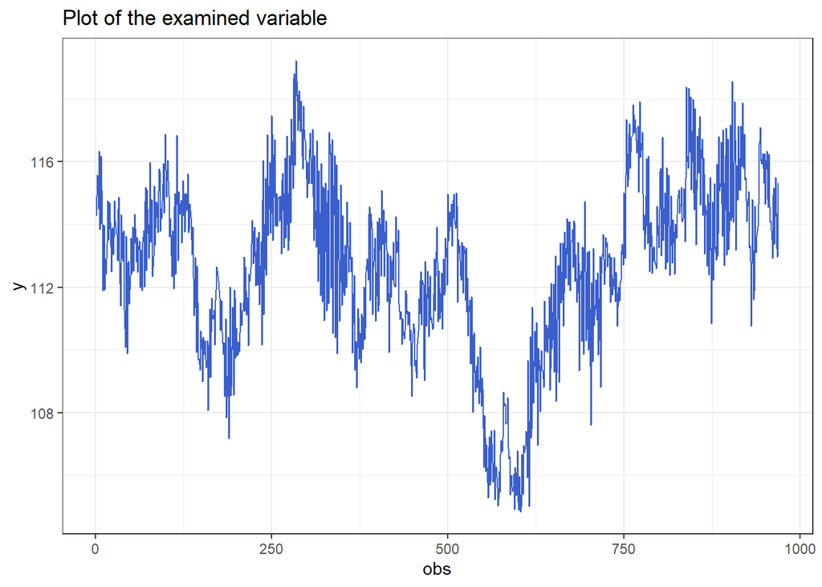

```
##   augmentations       adf      p_adf   bgodfrey         p_bg
## 1             0 -9.830022 0.01000000 76.5174399 2.182768e-18
## 2             1 -6.553005 0.01000000 65.6445807 5.400327e-16
## 3             2 -2.396557 0.16483980 13.0559430 3.023236e-04
## 4             3 -2.777293 0.06544566  0.1476036 7.008361e-01
## [1] 6
```

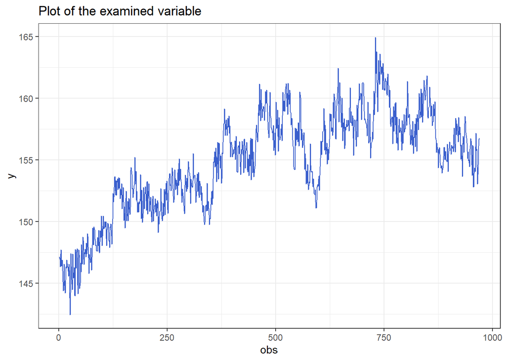

```
##   augmentations       adf      p_adf     bgodfrey            p_bg
## 1             0 -4.767596 0.01000000 29.309456037 0.0000000616939
## 2             1 -4.011524 0.01000000  4.715817993 0.0298863435826
## 3             2 -2.900562 0.04705682  0.076594920 0.7819660309845
## 4             3 -2.799490 0.06174559  0.001411268 0.9700330427797
## [1] 7
```

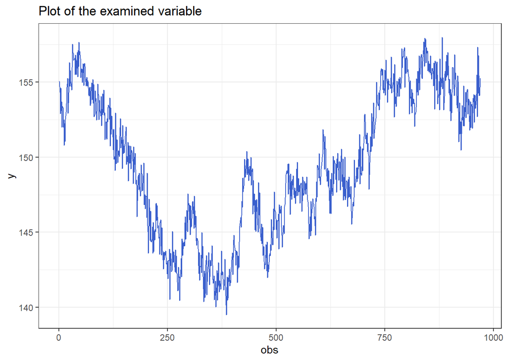

```
##   augmentations       adf     p_adf    bgodfrey         p_bg
## 1             0 -4.116867 0.0100000 221.5074145 4.242121e-50
## 2             1 -2.348256 0.1828967  12.2539356 4.642779e-04
## 3             2 -1.800951 0.3875013   2.0531535 1.518913e-01
## 4             3 -1.463236 0.5137525   0.1778976 6.731863e-01
## [1] 8
```

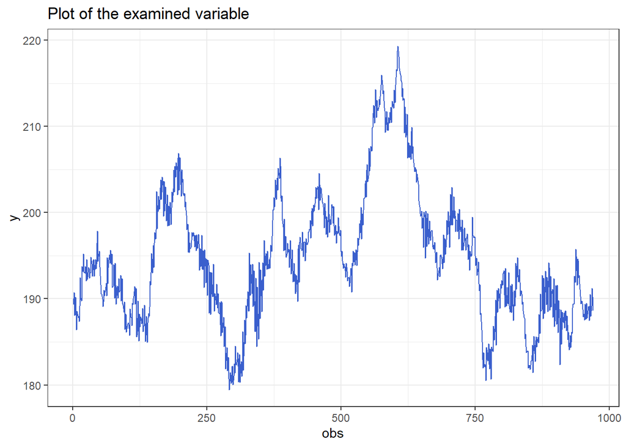

```
##   augmentations       adf      p_adf   bgodfrey         p_bg
## 1             0 -4.145998 0.01000000 131.684928 1.753540e-30
## 2             1 -2.730789 0.07319761  49.580168 1.904290e-12
## 3             2 -1.400554 0.53718577  22.738698 1.855924e-06
## 4             3 -1.809995 0.38412012   7.359676 6.670282e-03
## [1] 9
```

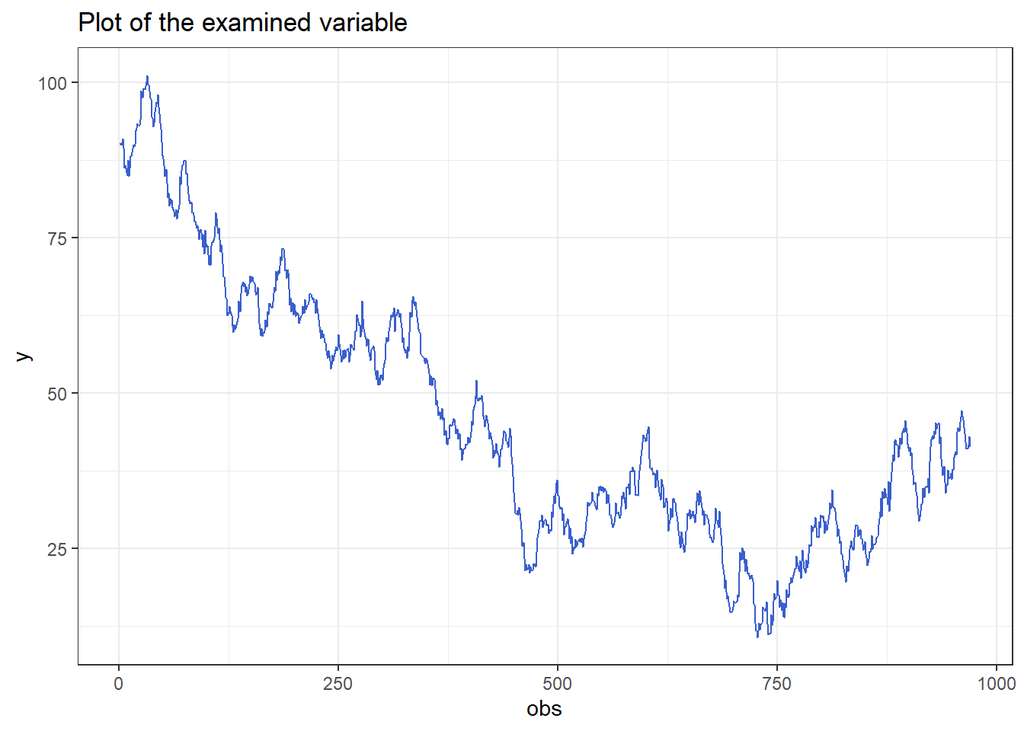

```
##   augmentations       adf     p_adf     bgodfrey        p_bg
## 1             0 -2.144272 0.2591542 10.561551209 0.001154643
## 2             1 -2.139001 0.2611247  0.249382529 0.617510194
## 3             2 -2.169225 0.2498256  0.172649592 0.677767688
## 4             3 -2.232105 0.2263188  0.004685051 0.945429466
## [1] 10
```

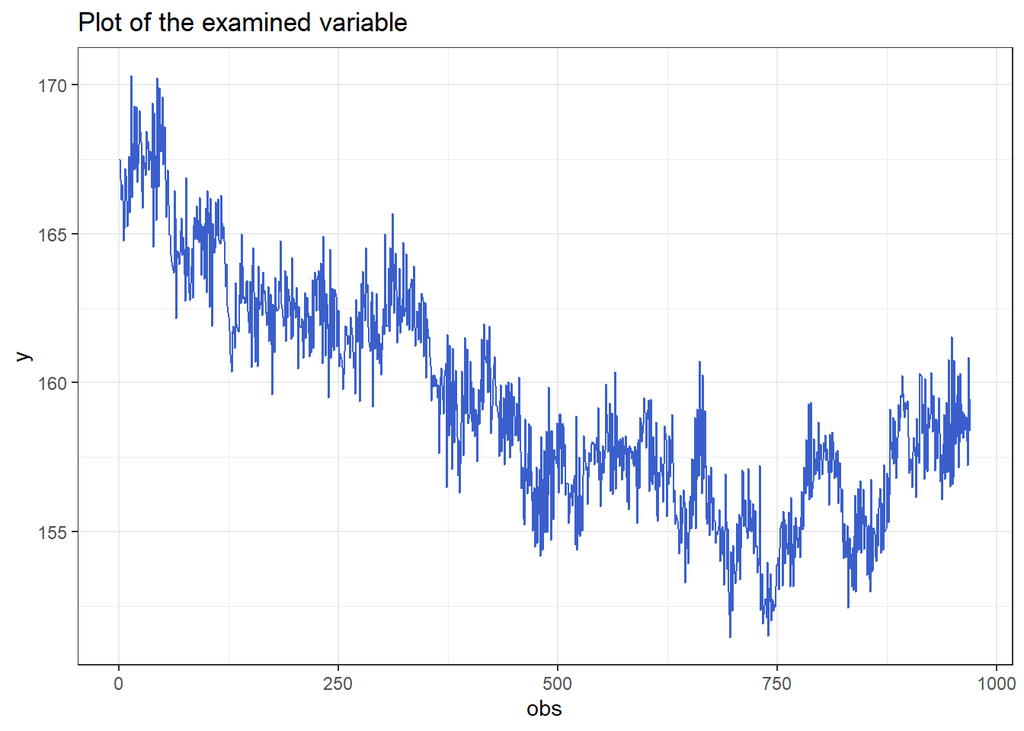

```
##   augmentations       adf     p_adf       bgodfrey         p_bg
## 1             0 -6.947311 0.0100000 173.5397528036 1.247655e-39
## 2             1 -4.234822 0.0100000  83.4749666662 6.452795e-20
## 3             2 -2.415998 0.1575721   0.2029343281 6.523627e-01
## 4             3 -2.328575 0.1902542   0.0005363636 9.815230e-01
```

```r
#-4
```

```r
data_train_xts_diff <- diff.xts(data_train_xts)

for (i in 1:10) {
  print(i)
  print(testdf(variable = data_train_xts_diff[,i],
               max.augmentations = 3))
}
```

```
## [1] 1
```

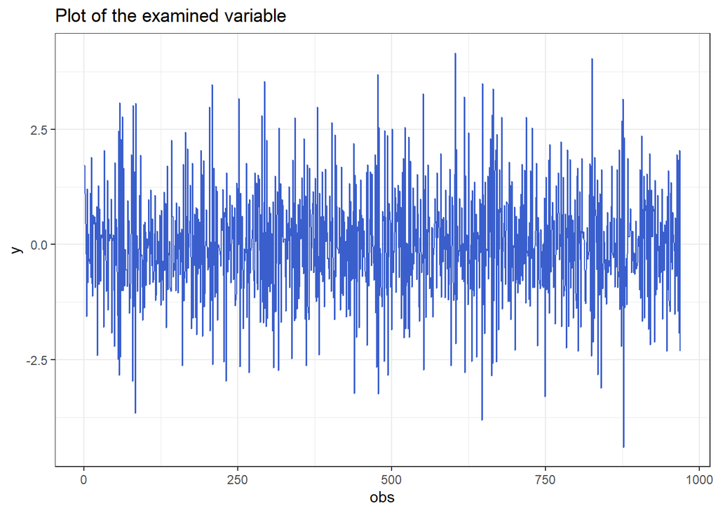

```
##   augmentations       adf p_adf  bgodfrey      p_bg
## 1             0 -57.26435  0.01 2.2435617 0.1341716
## 2             1 -29.78461  0.01 0.3975488 0.5283579
## 3             2 -27.06769  0.01 0.9268905 0.3356722
## 4             3 -17.77244  0.01 0.1955419 0.6583436
## [1] 2
```

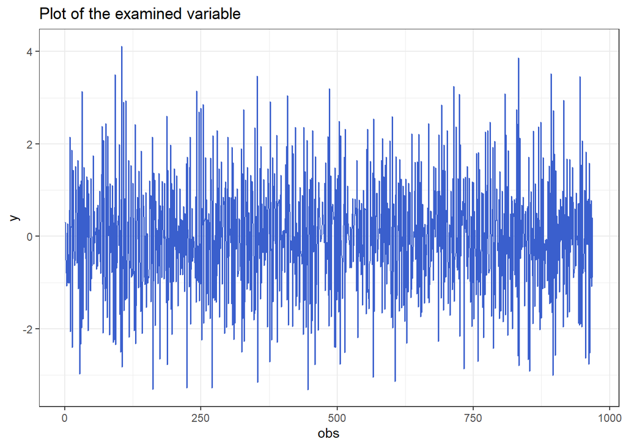

```
##   augmentations       adf p_adf  bgodfrey        p_bg
## 1             0 -56.64415  0.01 7.4813480 0.006234138
## 2             1 -32.10792  0.01 2.3416031 0.125959872
## 3             2 -30.35197  0.01 2.2137194 0.136788522
## 4             3 -18.39947  0.01 0.3831258 0.535935076
## [1] 3
```

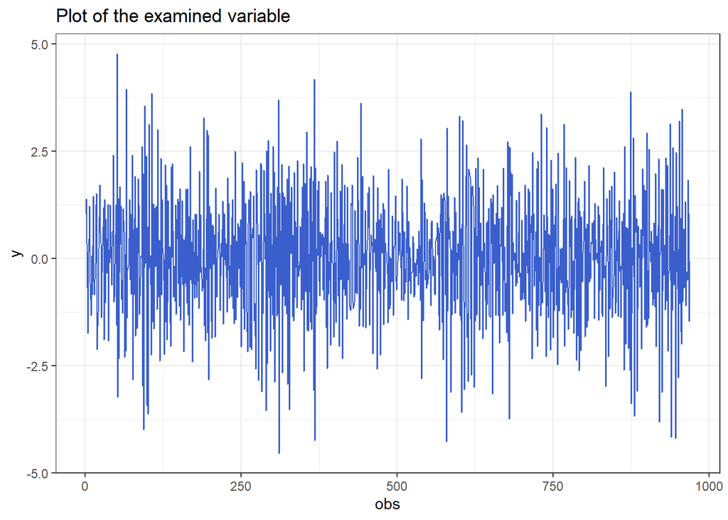

```
##   augmentations       adf p_adf   bgodfrey          p_bg
## 1             0 -53.56166  0.01  1.6342644 0.20111423918
## 2             1 -29.15995  0.01  0.4859731 0.48572911873
## 3             2 -28.13471  0.01 17.9351153 0.00002285649
## 4             3 -35.92099  0.01 10.9930522 0.00091454077
## [1] 4
```

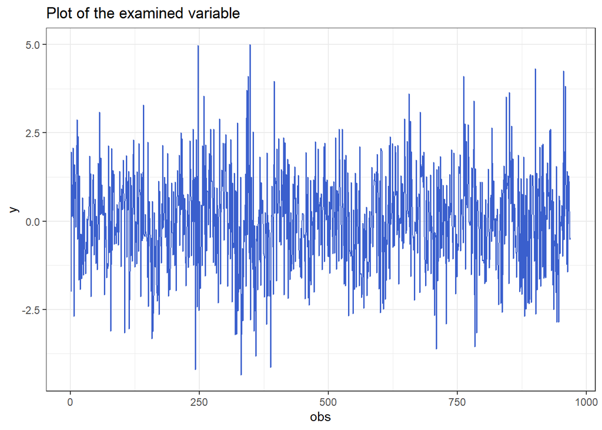

```
##   augmentations       adf p_adf    bgodfrey      p_bg
## 1             0 -31.65189  0.01 0.003055887 0.9559153
## 2             1 -22.37755  0.01 0.011044005 0.9163040
## 3             2 -13.10752  0.01 0.949271347 0.3299048
## 4             3 -10.91628  0.01 0.013142148 0.9087311
## [1] 5
```

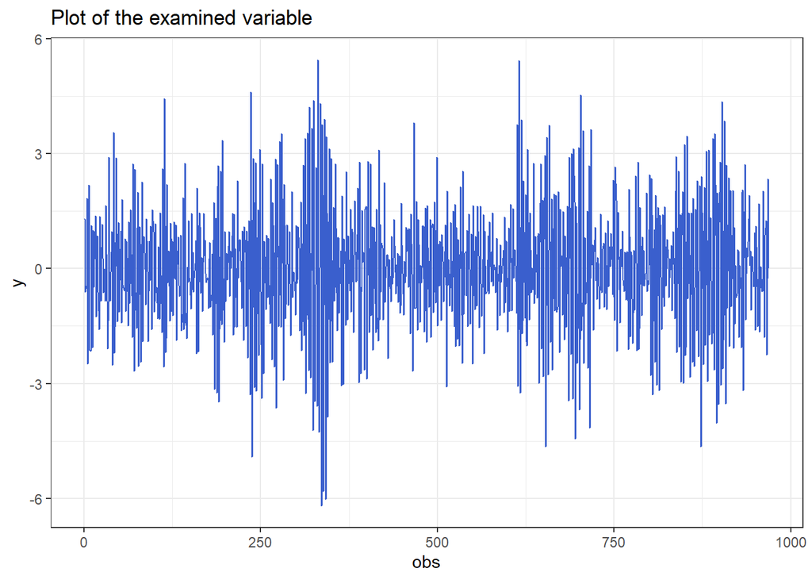

```
##   augmentations       adf p_adf   bgodfrey         p_bg
## 1             0 -47.67722  0.01 92.8719747 5.578893e-22
## 2             1 -71.91185  0.01 12.2783761 4.582369e-04
## 3             2 -24.51768  0.01  0.1066336 7.440098e-01
## 4             3 -17.90344  0.01  0.0171241 8.958868e-01
## [1] 6
```

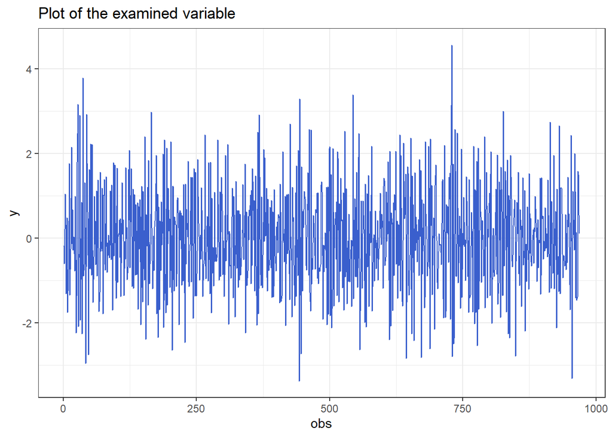

```
##   augmentations       adf p_adf    bgodfrey       p_bg
## 1             0 -38.02019  0.01 5.887733887 0.01524671
## 2             1 -36.37043  0.01 0.128593839 0.71989447
## 3             2 -24.29224  0.01 0.003189773 0.95496096
## 4             3 -20.06546  0.01 0.004339811 0.94747556
## [1] 7
```

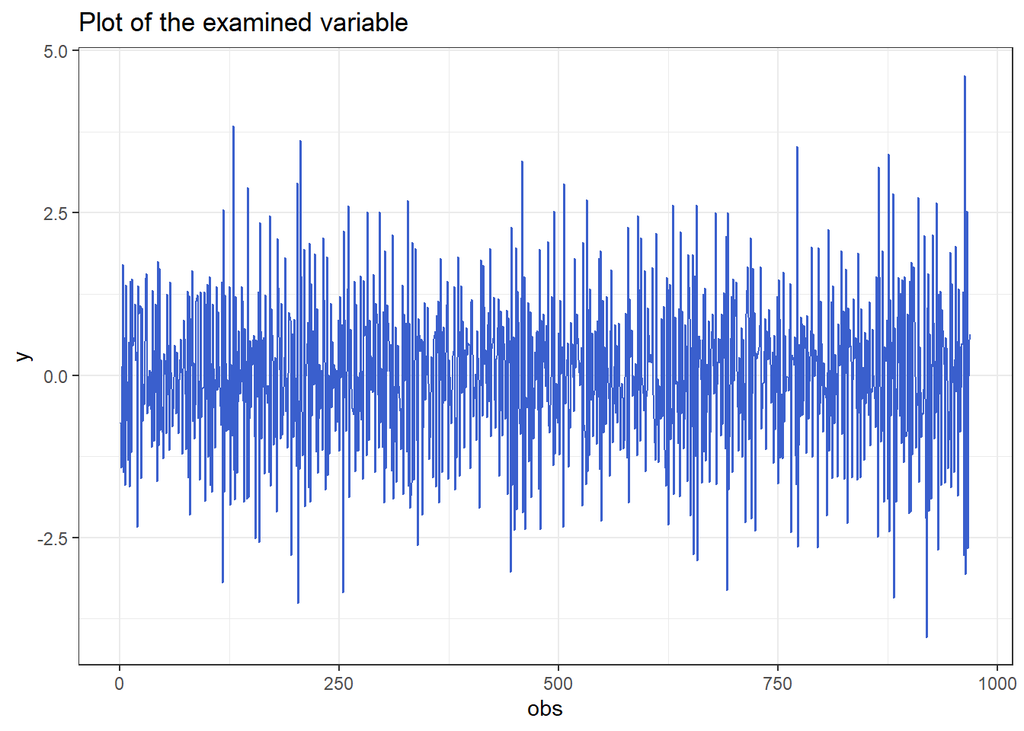

```
##   augmentations       adf p_adf     bgodfrey         p_bg
## 1             0 -54.12314  0.01 13.216469449 0.0002774998
## 2             1 -34.08871  0.01  2.196272451 0.1383449227
## 3             2 -28.38848  0.01  0.167910041 0.6819759392
## 4             3 -19.73146  0.01  0.006440234 0.9360375756
## [1] 8
```

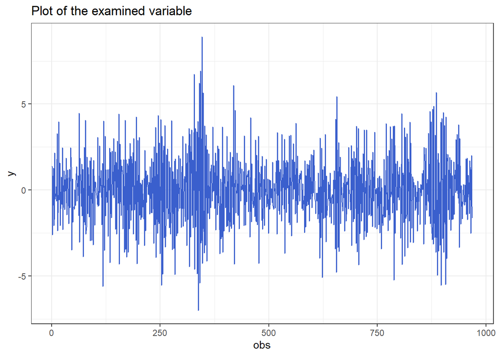

```
##   augmentations       adf p_adf    bgodfrey                 p_bg
## 1             0 -47.07606  0.01 52.94609441 0.000000000000342829
## 2             1 -51.58487  0.01 22.54794811 0.000002049633347787
## 3             2 -20.45938  0.01  7.02648047 0.008031304443305956
## 4             3 -12.05221  0.01  0.01360709 0.907137863285035539
## [1] 9
```

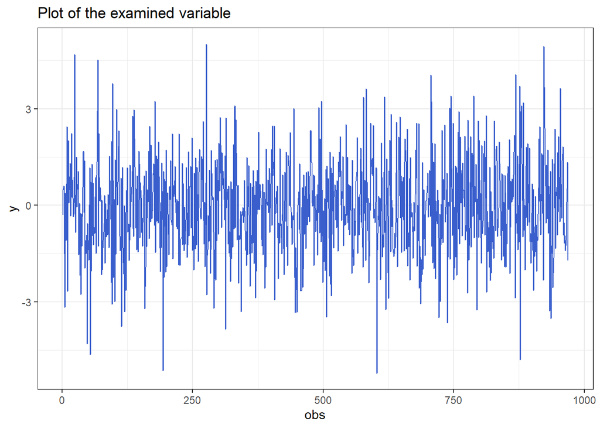

```
##   augmentations       adf p_adf    bgodfrey      p_bg
## 1             0 -34.50097  0.01 0.250342868 0.6168338
## 2             1 -19.76821  0.01 0.166048134 0.6836481
## 3             2 -15.30998  0.01 0.004487934 0.9465880
## 4             3 -13.28338  0.01 0.023997490 0.8768913
## [1] 10
```

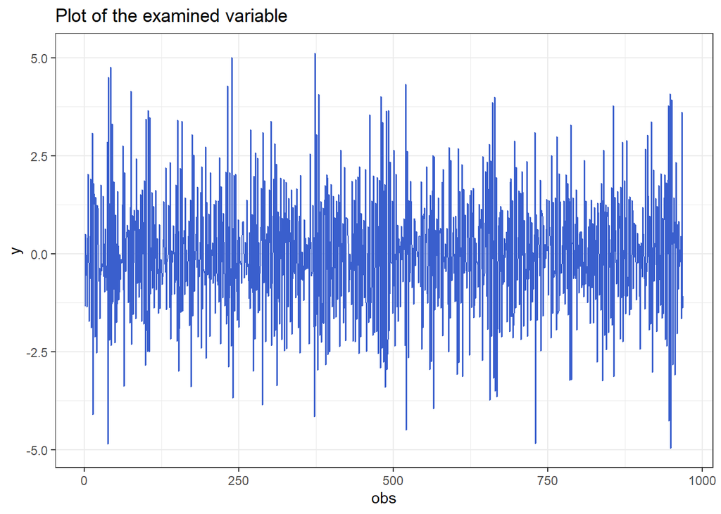

```
##   augmentations       adf p_adf      bgodfrey         p_bg
## 1             0 -53.11072  0.01 94.1099997253 2.984676e-22
## 2             1 -56.83705  0.01  0.2734461886 6.010294e-01
## 3             2 -27.95649  0.01  0.0012121352 9.722267e-01
## 4             3 -20.67058  0.01  0.0009328962 9.756337e-01
```

```r
#1 3 4 9
```

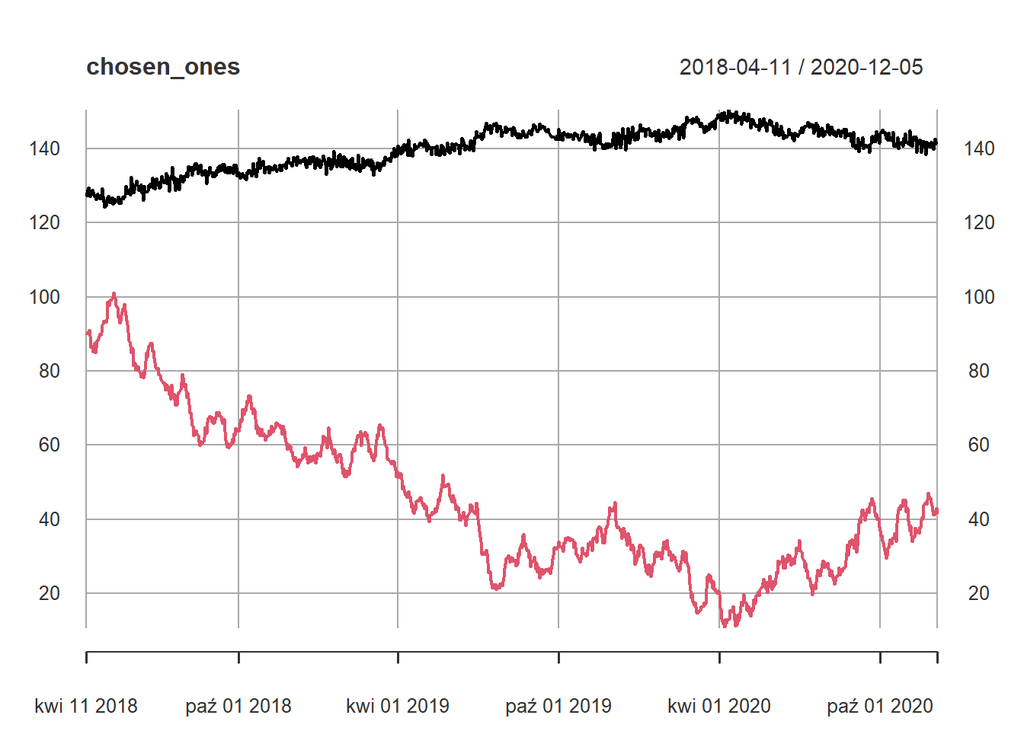

```r
data_train_xts_diff <- diff.xts(data_train_xts)


chosen_ones <- xts(order.by = data_train$X)

chosen_ones$first<- data_train_xts[,3]
chosen_ones$second<- data_train_xts[,9]

plot(chosen_ones)
```

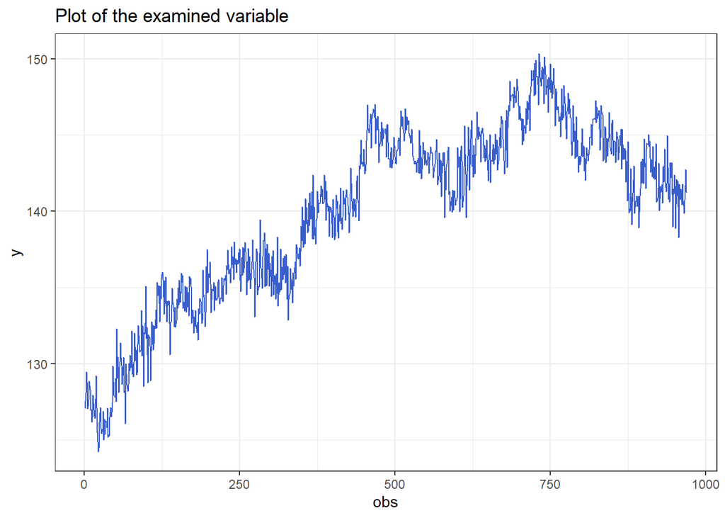

```
##   augmentations       adf      p_adf    bgodfrey         p_bg
## 1             0 -4.236743 0.01000000 216.4773277 5.306350e-49
## 2             1 -2.765207 0.06746044   1.3837714 2.394598e-01
## 3             2 -2.535913 0.11274324   0.4150733 5.194057e-01
## 4             3 -2.182995 0.24467802  17.5675287 2.772829e-05
```

```r
testdf(variable = chosen_ones$first, max.augmentations = 3)
```

```r
chosen_ones$diff_first <- diff.xts(chosen_ones$first)
chosen_ones$diff_second <- diff.xts(chosen_ones$second)
```

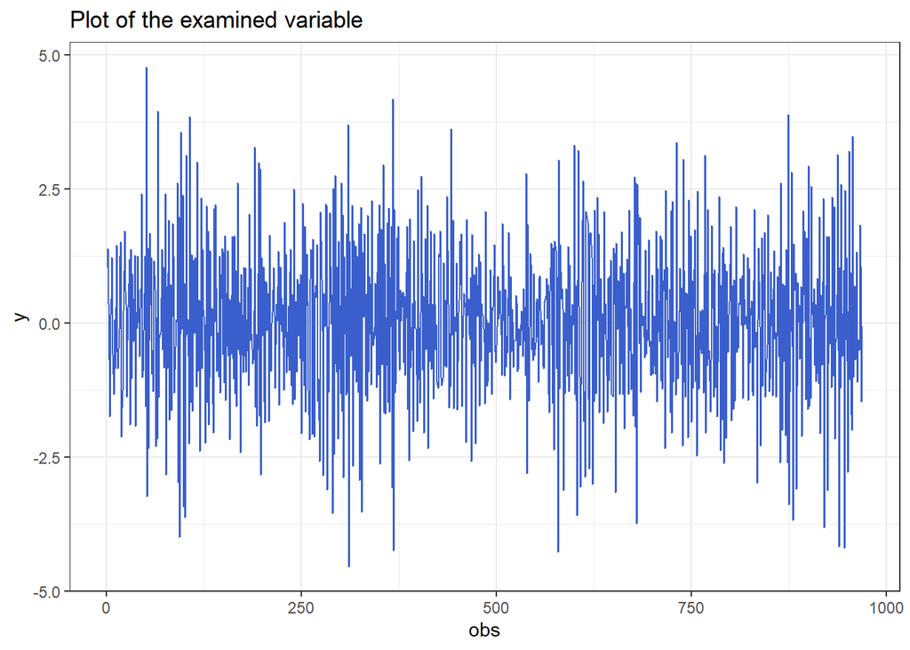

```
##   augmentations       adf p_adf   bgodfrey          p_bg
## 1             0 -53.56166  0.01  1.6342644 0.20111423918
## 2             1 -29.15995  0.01  0.4859731 0.48572911873
## 3             2 -28.13471  0.01 17.9351153 0.00002285649
## 4             3 -35.92099  0.01 10.9930522 0.00091454077
```

```r
testdf(variable = chosen_ones$diff_first, max.augmentations = 3)
```

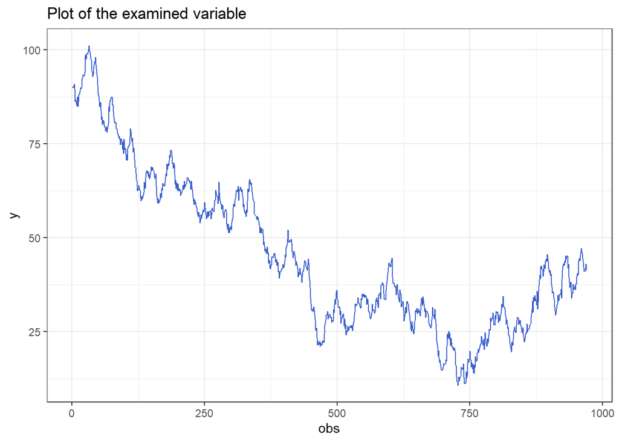

```
##   augmentations       adf     p_adf     bgodfrey        p_bg
## 1             0 -2.144272 0.2591542 10.561551209 0.001154643
## 2             1 -2.139001 0.2611247  0.249382529 0.617510194
## 3             2 -2.169225 0.2498256  0.172649592 0.677767688
## 4             3 -2.232105 0.2263188  0.004685051 0.945429466
```

```r
testdf(variable = chosen_ones$second, max.augmentations = 3)
```

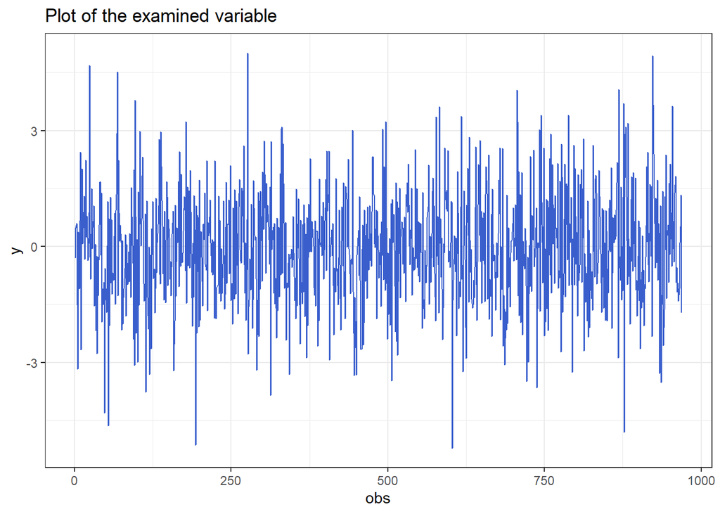

```
##   augmentations       adf p_adf    bgodfrey      p_bg
## 1             0 -34.50097  0.01 0.250342868 0.6168338
## 2             1 -19.76821  0.01 0.166048134 0.6836481
## 3             2 -15.30998  0.01 0.004487934 0.9465880
## 4             3 -13.28338  0.01 0.023997490 0.8768913
```

```r
testdf(variable = chosen_ones$diff_second, max.augmentations = 3)
```

Both series integrated of order one (I(1))

## 2.1 Checking for cointegration relation

```r
cointegration <- lm(first ~ second, data = chosen_ones)

summary(cointegration)
```

```
##
## Call:
## lm(formula = first ~ second, data = chosen_ones)
##
## Residuals:
##     Min      1Q  Median      3Q     Max
## -4.9698 -0.9716  0.0243  0.9699  4.5251
##
## Coefficients:
##               Estimate Std. Error t value Pr(>|t|)
## (Intercept) 152.195497   0.107127  1420.7   <2e-16 ***
## second       -0.271123   0.002145  -126.4   <2e-16 ***
## ---
## Signif. codes:  0 '***' 0.001 '**' 0.01 '*' 0.05 '.' 0.1 ' ' 1
##
## Residual standard error: 1.395 on 968 degrees of freedom
## Multiple R-squared:  0.9429, Adjusted R-squared:  0.9428
## F-statistic: 1.598e+04 on 1 and 968 DF,  p-value: < 2.2e-16
```

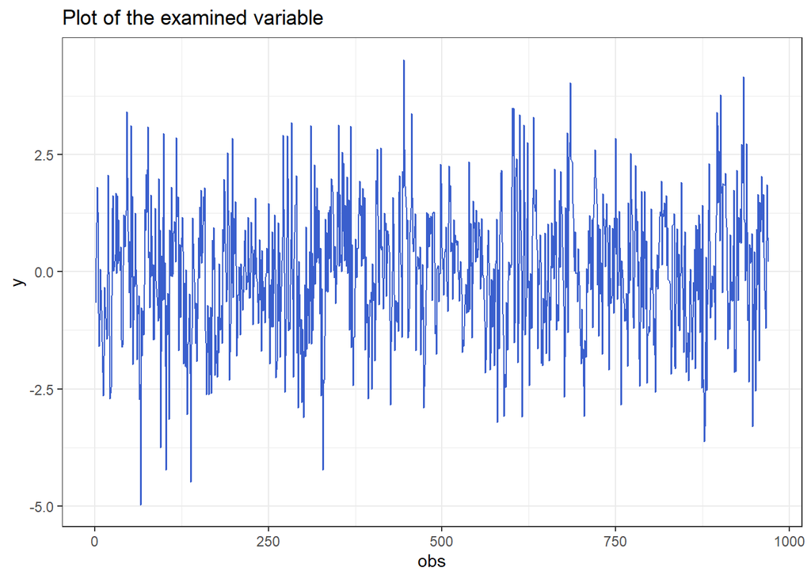

```
##   augmentations       adf p_adf  bgodfrey       p_bg
## 1             0 -20.96279  0.01 6.0380630 0.01400064
## 2             1 -14.01208  0.01 1.6127460 0.20410623
## 3             2 -15.58198  0.01 0.2980738 0.58509251
## 4             3 -12.68463  0.01 1.0580606 0.30365793
```

```r
testdf(variable = residuals(cointegration), max.augmentations = 3)
```

Coefficients:  
Estimate Std. Error t value Pr(>|t|)  
(Intercept) 152.195497 0.107127 1420.7 <2e-16 ***  
second -0.271123 0.002145 -126.4 <2e-16***  
The cointegrating vector is: 1, -152.195497, 0.271123 which defines the cointegrating relationship as:  
residuals = 1 * first - 152.195497 + 0.271123 * second

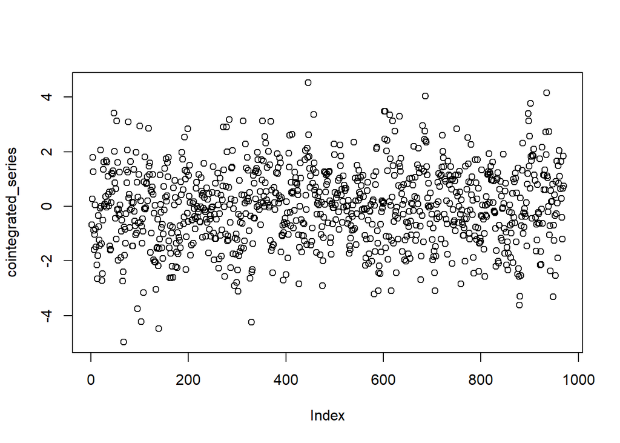

```r
cointegrated_series <- lag.xts(residuals(cointegration))

chosen_ones$lag_resid_coint <- cointegrated_series

plot(cointegrated_series)
```

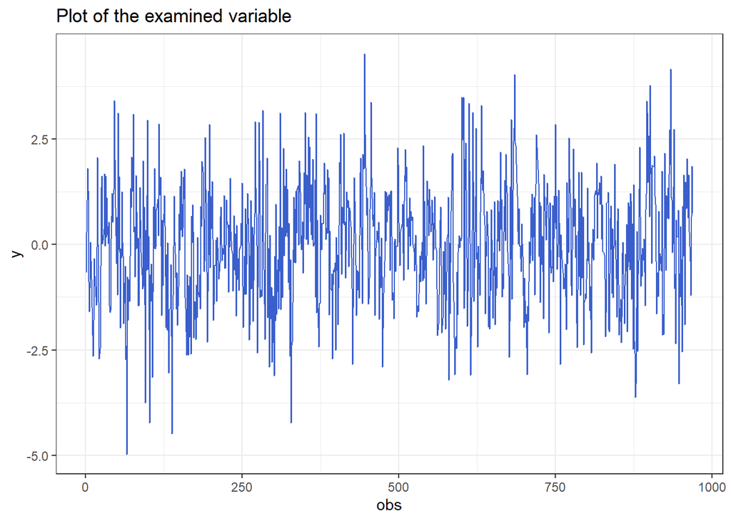

```
##   augmentations       adf p_adf  bgodfrey       p_bg
## 1             0 -20.94800  0.01 6.0366101 0.01401216
## 2             1 -13.98500  0.01 1.6175587 0.20343253
## 3             2 -15.55591  0.01 0.2946179 0.58727637
## 4             3 -12.67620  0.01 1.0504432 0.30540504
```

```r
testdf(variable = cointegrated_series, max.augmentations = 3)
```

# 3. ARIMA models

## 3.1 ARIMA for first time series (from before we know that this series is I(1))

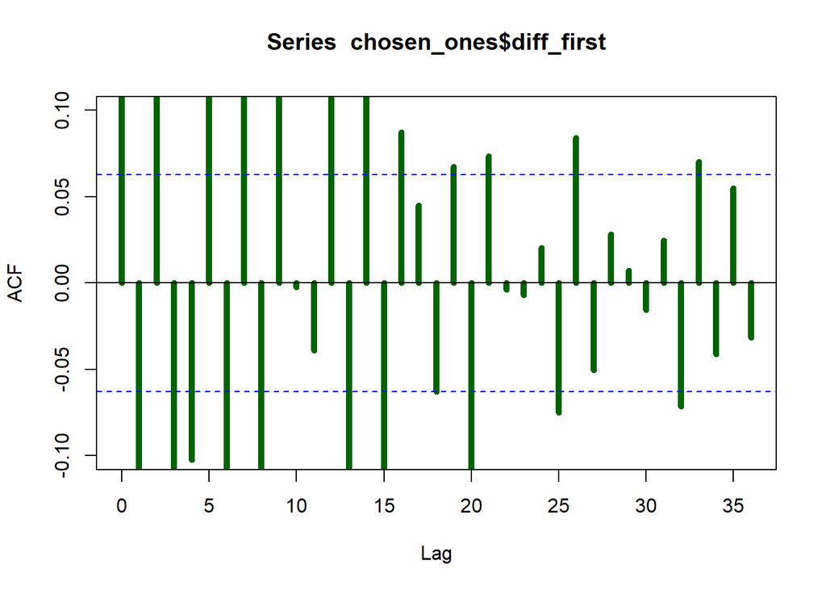

```r
acf(chosen_ones$diff_first,
    lag.max = 36, # max lag for ACF
    ylim = c(-0.1, 0.1),   # limits for the y axis - we give c(min, max)
    lwd = 5,               # line width
    col = "dark green",
    na.action = na.pass)   # do not stop if there are missing values in the data
```

```r
par(mfrow = c(2, 1))
```

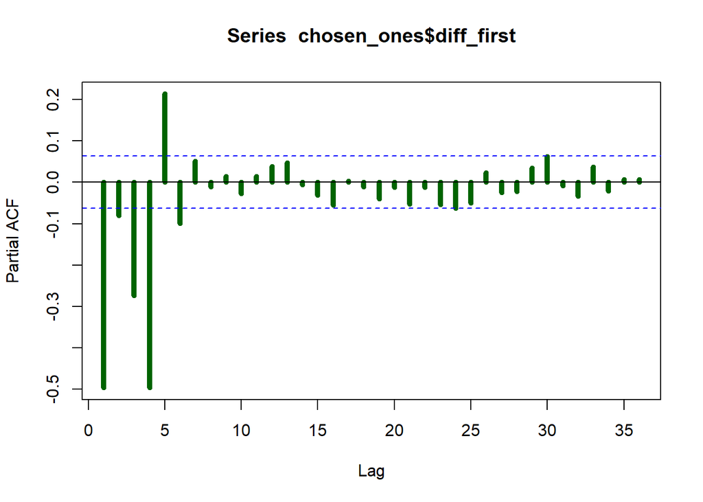

```r
pacf(chosen_ones$diff_first,
     lag.max = 36,
     lwd = 5, col = "dark green",
     na.action = na.pass)
```

```r
par(mfrow = c(1, 1))
```